# Stepwise Forward Regression on GPP

Ananda Kurth

2025-06-01

# Chapter 9 - Report Exercises

## 2. Setup and Data Loading

```r
# Load the dataset prepared for stepwise regression.
df <- read_csv("../data/df_for_stepwise_regression.csv", show_col_types = FALSE)

# Remove any rows with missing values in GPP or predictors.
df <- df |>
  drop_na() |>
  filter(!is.na(GPP_NT_VUT_REF))

# Display first few rows to confirm column names and data structure
head(df)
```

```
## # A tibble: 6 × 17
##   siteid TIMESTAMP    TA_F SW_IN_F LW_IN_F VPD_F  PA_F   P_F  WS_F TA_F_MDS
##   <chr>  <date>      <dbl>   <dbl>   <dbl> <dbl> <dbl> <dbl> <dbl>    <dbl>
## 1 CH-Dav 2006-05-30 -0.776    183.    271. 1.08   82.8   5    3.36   -0.776
## 2 CH-Dav 2006-05-31 -1.08     266.    257. 0.77   83.2   1.6  2.57   -1.08
## 3 CH-Dav 2006-06-01 -0.671    166.    272. 0.938  83.7   1.9  2.24   -0.671
## 4 CH-Dav 2006-06-02 -0.638    192.    265. 1.22   83.9   0.1  2.51   -0.638
## 5 CH-Dav 2006-06-03  1.93     202.    259. 1.68   84.1   0.2  1.75    1.93
## 6 CH-Dav 2006-06-04  2.78     104.    273. 0.761  83.9   6.4  1.46    2.78
## # ℹ 7 more variables: SW_IN_F_MDS <dbl>, LW_IN_F_MDS <dbl>, VPD_F_MDS <dbl>,
## #   CO2_F_MDS <dbl>, PPFD_IN <dbl>, GPP_NT_VUT_REF <dbl>, USTAR <dbl>
```

## 3. Evaluation of all bivariate models (single predictor)

```r
# 1. Set the number of predictors to be considered to p = 1.
response_var <- "GPP_NT_VUT_REF"
predictors <- names(df[, sapply(df, is.numeric)]) |> # set all other variables as predictors
  setdiff(response_var)


# 2. Fit all regression models with p predictors and compute their R2.
models <- list()
for (i in predictors) {
  model <- lm(df[[response_var]] ~ df[[i]])
  models[[i]] <- model
}

# 3. Select the model with p predictors that achieves the highest R2 (best fitting model) and compute its AIC.
r2_values <- sapply(models, function(x)
  summary(x)$r.squared) # calculate R2 values
best_predictor <- predictors[which.max(r2_values)] # find the highest R2 value
best_model     <- models[[best_predictor]] # find the model with that R2 value
best_aic       <- AIC(best_model) # Calculate the AIC of that model

# Report results
cat("Best single‐predictor model:\n")
```

```
## Best single‐predictor model:
```

```r
cat("  Predictor: ", best_predictor, "\n")
```

```
##   Predictor:  PPFD_IN
```

```r
cat("  R²:        ", round(summary(best_model)$r.squared, 4), "\n")
```

```
##   R²:         0.3628
```

```r
cat("  AIC:       ", round(best_aic, 2), "\n")
```

```
##   AIC:        45682.99
```

### 3.1. Visualization

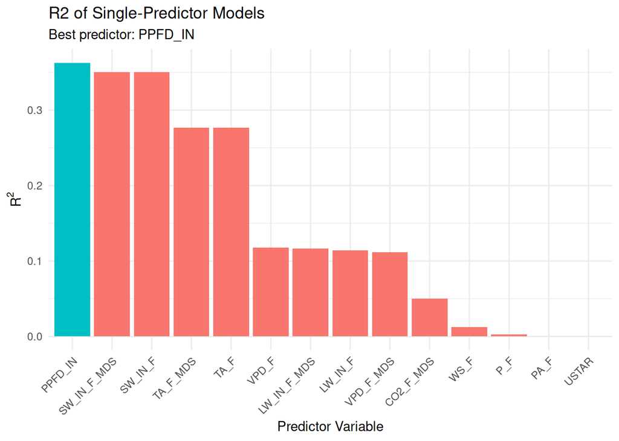

```r
# Prepare data for visualization
r2_df <- data.frame(Predictor = predictors, R2 = r2_values) |>
  arrange(desc(R2)) |> # descending
  mutate(Predictor = factor(Predictor, levels = Predictor))  # Keep order in plot

# Plot
ggplot(r2_df, aes(
  x = Predictor,
  y = R2,
  fill = Predictor == best_predictor
)) +
  geom_bar(stat = "identity") +
  labs(
    title = "R2 of Single-Predictor Models",
    subtitle = paste("Best predictor:", best_predictor),
    x = "Predictor Variable",
    y = expression(R^2)
  ) +
  theme_minimal() +
  theme(legend.position = "none",
        axis.text.x = element_text(angle = 45, hjust = 1))
```

> Interpretation: The most significant predictor is PPFD_IN (incoming photosynthetic photon flux density), explaining about 36.3% of the variance in GPP (R² ≈ 0.363). The AIC is approximately 45683. However, a high R² doesn’t guarantee predictive power due to potential issues like redundancy, interaction effects, and autocorrelation.

## 4. Stepwise Forward Regression

Having identified PPFD_IN as the strongest univariate predictor, I will move on to a multivariate model which adds one predictor at a time, prioritizing the one that maximizes R² and lowers AIC. The process stops when adding any remaining predictor increases AIC, indicating a poorer fit.

```r
stepwise_forward_selection <- function(df, response_var) {
  # List all numeric variables
  numeric_vars <- names(df)[sapply(df, is.numeric)]
  # Exclude the response itself
  predictors <- setdiff(numeric_vars, response_var)

  # Initialize storage
  selected_predictors <- c()
  best_model <- NULL
  best_aic <- Inf
  trace <- list()

  # Iterate until no predictors remain
  for (p in 1:length(predictors)) {
    remaining <- setdiff(predictors, selected_predictors)
    if (length(remaining) == 0)
      # stop if no predictors remain
      break

    # Fit candidate models by adding each remaining predictor in turn
    models <- list()

    for (pred in remaining) {
      formula <- as.formula(paste(response_var, "~", paste(
        c(selected_predictors, pred), collapse = "+"
      ))) # formula
      model <- lm(formula, data = df) # calculate lm
      models[[pred]] <- model
    }

    # Among these, choose the one with the highest R2
    r2_scores <- sapply(models, function(m)
      summary(m)$r.squared) # calculate all R2 values
    best_new_predictor <- names(which.max(r2_scores)) # find the highest R2
    best_new_model <- models[[best_new_predictor]] # Find the corresponding model
    best_new_aic <- AIC(best_new_model) # Calculate the AIC of that model


    # If AIC improves, accept this predictor; otherwise, stop
    if (best_new_aic < best_aic) {
      selected_predictors <- c(selected_predictors, best_new_predictor)
      best_model <- best_new_model
      best_aic <- best_new_aic
      trace[[p]] <- list(
        step = p,
        added = best_new_predictor,
        aic = best_new_aic,
        r2 = summary(best_new_model)$r.squared
      )
    } else {
      break
    }
  }

  return(
    list(
      model = best_model,
      predictors = selected_predictors,
      aic = best_aic,
      r2 = if (!is.null(best_model))
        summary(best_model)$r.squared
      else
        NA,
      trace = trace
    )
  )
}
```

```r
# Apply the function to our dataframe
result   <- stepwise_forward_selection(df, response_var = "GPP_NT_VUT_REF")
trace_df <- bind_rows(lapply(result$trace, as_tibble))
```

### 4.1 Examination of Stepwise Trace

```r
do.call(rbind, lapply(result$trace, as.data.frame))
```

```
##    step     added      aic        r2
## 1     1   PPFD_IN 45682.99 0.3627837
## 2     2   LW_IN_F 44501.85 0.4374452
## 3     3     VPD_F 43554.30 0.4909870
## 4     4  TA_F_MDS 43370.32 0.5008611
## 5     5      WS_F 43271.22 0.5061483
## 6     6     USTAR 42978.11 0.5212628
## 7     7   SW_IN_F 42907.76 0.5248973
## 8     8       P_F 42872.84 0.5267412
## 9     9 CO2_F_MDS 42855.60 0.5276995
## 10   10      PA_F 42838.15 0.5286660
```

### 4.2 Final Model Performance

```r
cat("Final model AIC: ", round(result$aic, 2), "\n")
```

```
## Final model AIC:  42838.15
```

```r
cat("Final model R²:  ", round(result$r2, 4), "\n")
```

```
## Final model R²:   0.5287
```

> The best single predictor model had an R² of about 0.3628 and an AIC of around 45683. The final model, incorporating ten predictors, increased the R² to roughly 0.5287 and reduced the AIC to about 42838. This suggests that the nine additional variables improved the model’s ability to explain variance in GPP. The drop in AIC from approximately 45683 to 42838 shows that the model fit improved significantly.

### 4.3. Visualizing Stepwise Progress

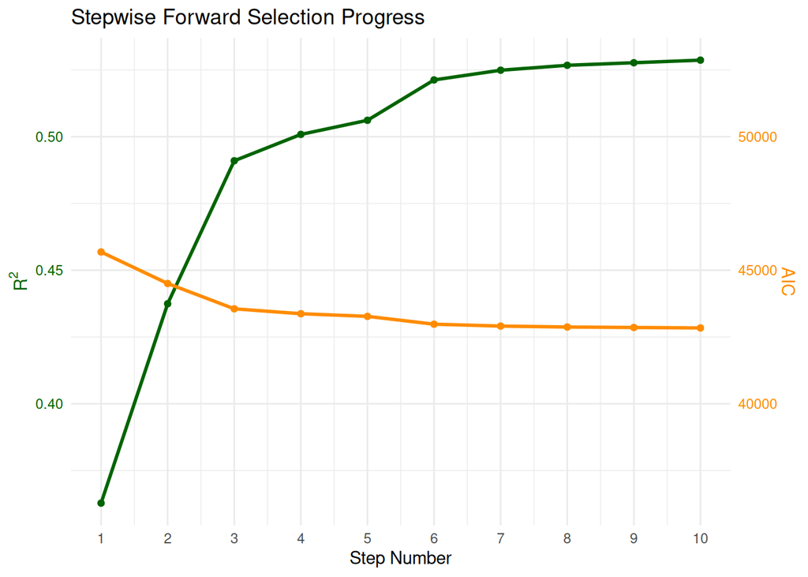

```r
# Build a data frame for plotting
trace_df <- tibble(
  step      = seq_along(result$trace),
  predictor = sapply(result$trace, function(x)
    x$added),
  aic       = sapply(result$trace, function(x)
    x$aic),
  r2        = sapply(result$trace, function(x)
    x$r2)
)

ggplot(trace_df, aes(x = step)) +
  geom_line(aes(y = r2), color = "darkgreen", linewidth = 1) +
  geom_point(aes(y = r2), color = "darkgreen", linewidth = 2) +
  geom_line(aes(y = aic / 1e5),
            color = "darkorange",
            linewidth = 1) +  # scale AIC by 1e5
  geom_point(aes(y = aic / 1e5),
             color = "darkorange",
             linewidth = 2) +
  scale_y_continuous(name        = expression(R^2),
                     sec.axis    = sec_axis( ~ . * 1e5, name = "AIC")) +
  scale_x_continuous(breaks = trace_df$step) +
  labs(title = "Stepwise Forward Selection Progress", x     = "Step Number", y     = expression(R^2)) +
  theme_minimal() +
  theme(
    axis.title.y.left   = element_text(color = "darkgreen"),
    axis.text.y.left    = element_text(color = "darkgreen"),
    axis.title.y.right  = element_text(color = "darkorange"),
    axis.text.y.right   = element_text(color = "darkorange")
  )
```

> The plot shows the relationship between added predictors, R² and AIC. The green curve shows that R² increases with each predictor, though the rate of increase diminishes over time. In contrast, the orange curve indicates that AIC decreases until it levels off, where the model does not improve any further.

## 5. Interpretation and Discussion

Although adding more predictors generally increases the R² value, the improvements become smaller, especially for related variables like radiation and temperature.

```r
# Manually define ecological descriptions for each predictor for my own interpretation
description_map <- c(
  "PPFD_IN"   = "Photosynthetic photon flux density, incoming",
  "LW_IN_F"   = "Longwave radiation, incoming",
  "VPD_F_MDS" = "Vapor pressure deficit (gap‐filled)",
  "TA_F_MDS"  = "Air temperature (gap‐filled)",
  "WS_F"      = "Wind speed",
  "USTAR"     = "Friction velocity (u*)",
  "SW_IN_F"   = "Shortwave radiation, incoming",
  "P_F"       = "Precipitation",
  "CO2_F_MDS" = "CO₂ mole fraction (gap‐filled)",
  "PA_F"      = "Atmospheric pressure",
  "VPD_F"     = "Vapor Pressure Deficit"
)

# Create a tibble that shows step #, variable, and description
tibble(
  Step        = seq_along(result$predictors),
  Variable    = result$predictors,
  Description = description_map[result$predictors]
)
```

```
## # A tibble: 10 × 3
##     Step Variable  Description
##    <int> <chr>     <chr>
##  1     1 PPFD_IN   Photosynthetic photon flux density, incoming
##  2     2 LW_IN_F   Longwave radiation, incoming
##  3     3 VPD_F     Vapor Pressure Deficit
##  4     4 TA_F_MDS  Air temperature (gap‐filled)
##  5     5 WS_F      Wind speed
##  6     6 USTAR     Friction velocity (u*)
##  7     7 SW_IN_F   Shortwave radiation, incoming
##  8     8 P_F       Precipitation
##  9     9 CO2_F_MDS CO₂ mole fraction (gap‐filled)
## 10    10 PA_F      Atmospheric pressure
```